# Univariate Time Series Analysis

### Kevin Sheppard

# Data

- All data from the Federal Reserve Economics Database (FRED) excluding the VWM return.
- Data from 1959 until end of 2020.

### Series

- Industrial Production
- Curvature of the Yield Curve

$$ \left(Y_{10}-Y_5\right)-\left(Y_{5}-Y_{1}\right) $$

- Default Rate

$$ Y_{Baa} - Y_{Aaa} $$

- US Construction workers
- Housing Starts (Not Seasonally Adjusted)
- Value-Weighted Market Return (CRSP)
- Simulated AR(2)

$$ Y_t = 10 + 1.4 Y_{t-1} - 0.5 Y_{t-2} + \epsilon_t $$

# Industrial Production Index

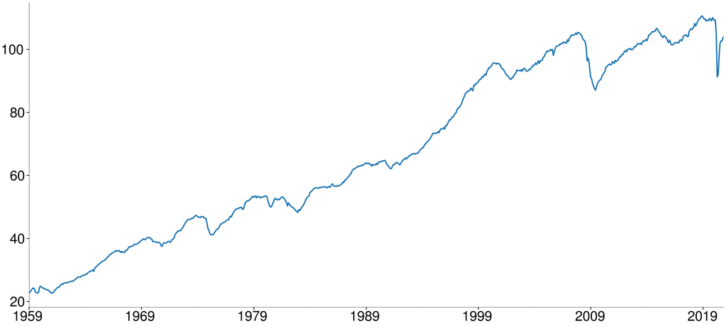

```python
plot(orig.INDPRO)
```

# Housing Starts (NSA)

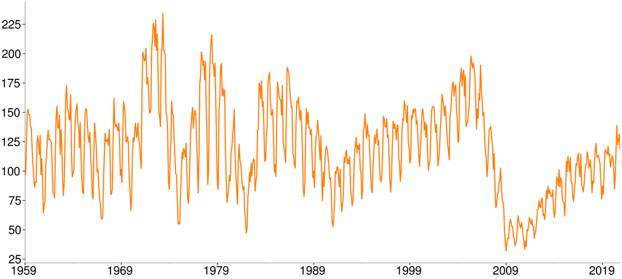

```python
plot(orig.HOUSTNSA)
```

# Curvature of the Yield Curve

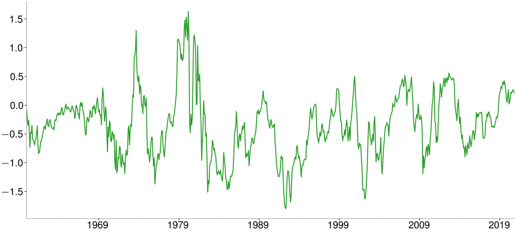

```python
plot(curve)
```

# The Default Premium

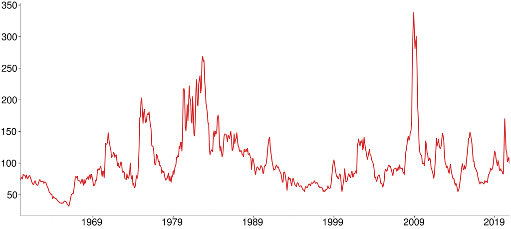

```python
plot(default)
```

# US Construction Workers

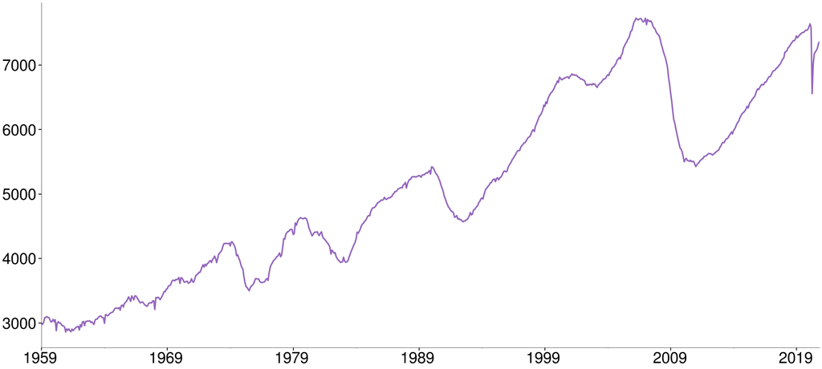

```python
plot(orig.USCONS)
```

# Simulated AR(2) Data

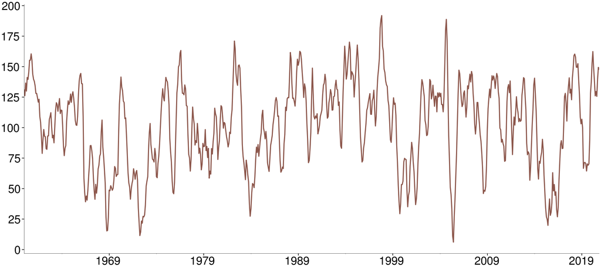

```python
plot(sim)
```

# Covariance Stationarity

A stochastic process $Y_{t}$ is covariance stationary if

$$ \begin{align} \mathrm{E}\left[Y_{t}\right] &=\mu \hspace{1em}\text{ for }t=1,2,\ldots \\ \mathrm{V}\left[Y_{t}\right]&=\sigma^{2}<\infty \hspace{1em}\text{ for }t=1,2,\ldots \\ \mathrm{E}\left[(Y_{t}-\mu)(Y_{t-s}-\mu)\right]&=\gamma_{s} \hspace{1em}\text{ for }t=1,2,\ldots,s=1,2,\ldots,t-1 \\ \end{align} $$

# Transformations

- Natural log ($\ln$): commonly applied to series that are non-negative
- Difference ($\Delta Y_t = Y_t - Y_{t-1}$): removes trends
- Log difference ($\Delta \ln Y_t$): growth rate
- Year-over-year Log Difference ($\Delta_12 \ln Y_t$): annual growth rate, removes *seasonality*

# Year-over-Year Industrial Production Growth

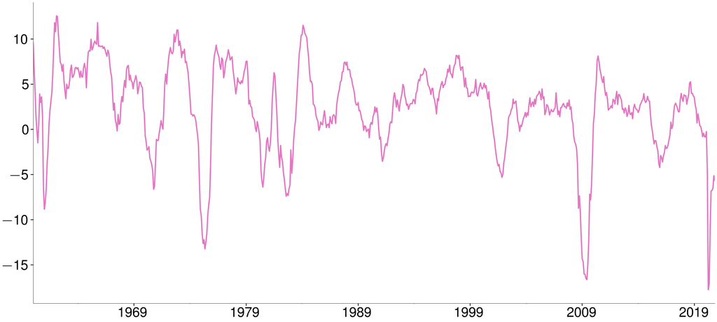

```python
plot(indpro)
```

# Housing Start Growth Rate

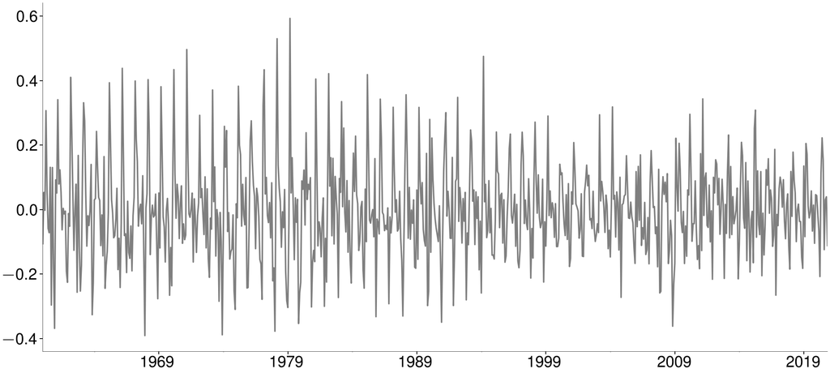

```python
plot(housing)
```

# US Construction Workers Growth Rate

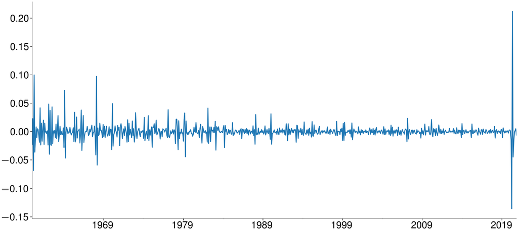

```python
plot(uscons)
```

# Value-Weighted Market

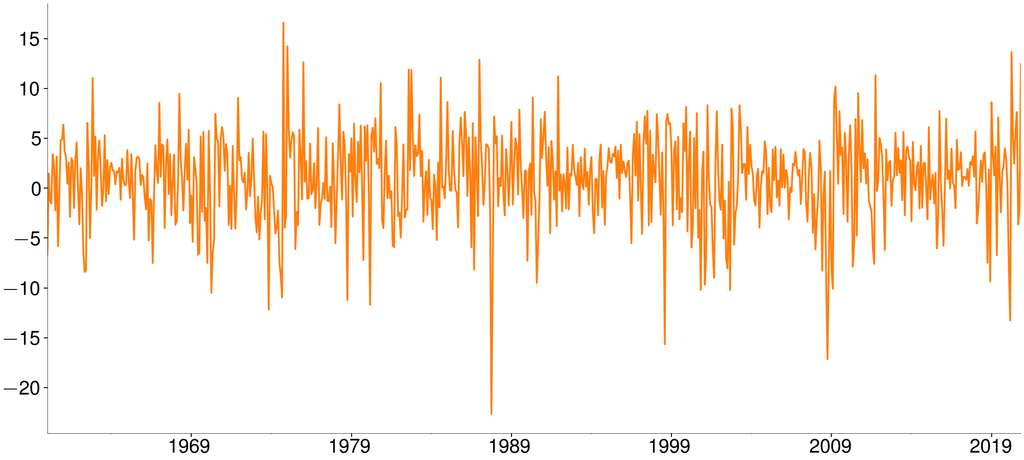

```python
plot(vwm)
```

# Identifying Candidate Models

- Exploit pattern and autocorrelation and partial autocorrelation
- Autocorrelation

$$ \textrm{Corr}(Y_t,Y_{t-s}) = \frac{\gamma_s}{\gamma_0} $$

- Partial Autocorrelation

$$ \textrm{Corr}(Y_t,Y_{t-s}|Y_{t-1},\ldots,Y_{t-s+1}) $$

# YoY Industrial Production Growth

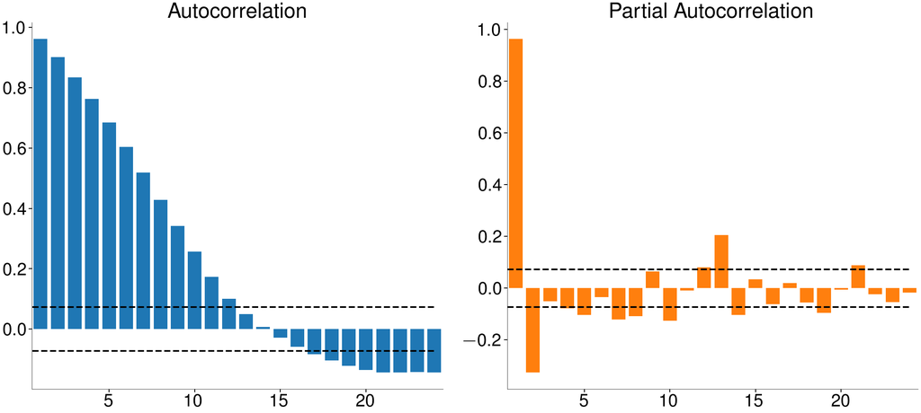

```python
acf_pacf_plot(indpro, 24)
```

# Curvature

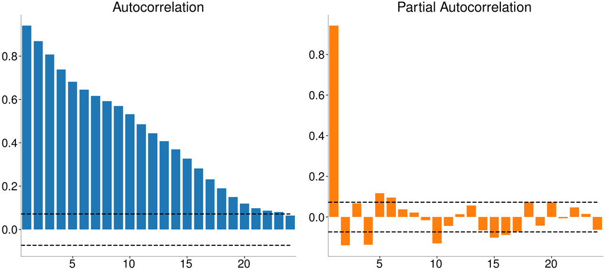

```python
acf_pacf_plot(curve, 24)
```

# Default Premium

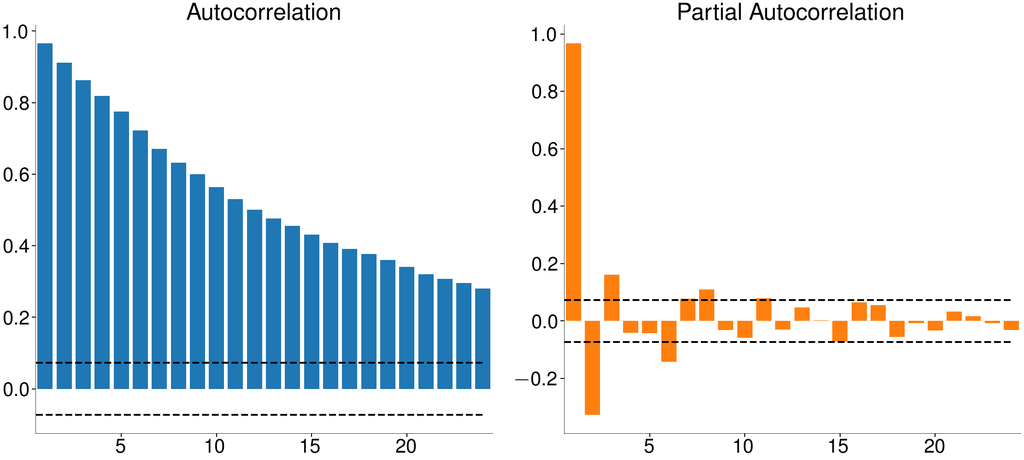

```python
acf_pacf_plot(default, 24)
```

# Simulated AR(2)

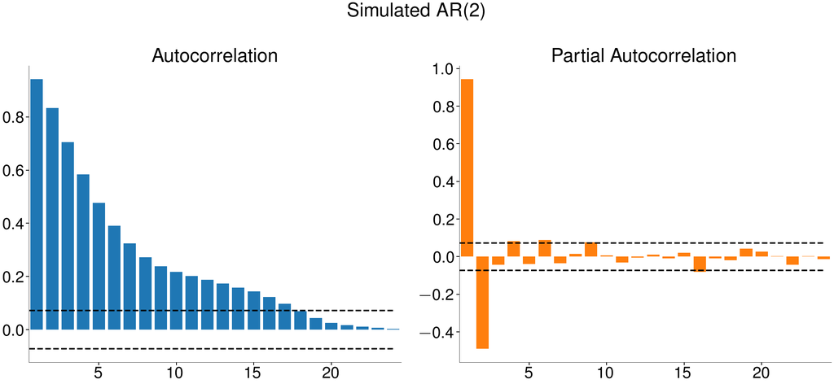

```python
acf_pacf_plot(sim, 24, title="Simulated AR(2)")
```

# Construction Worker Growth

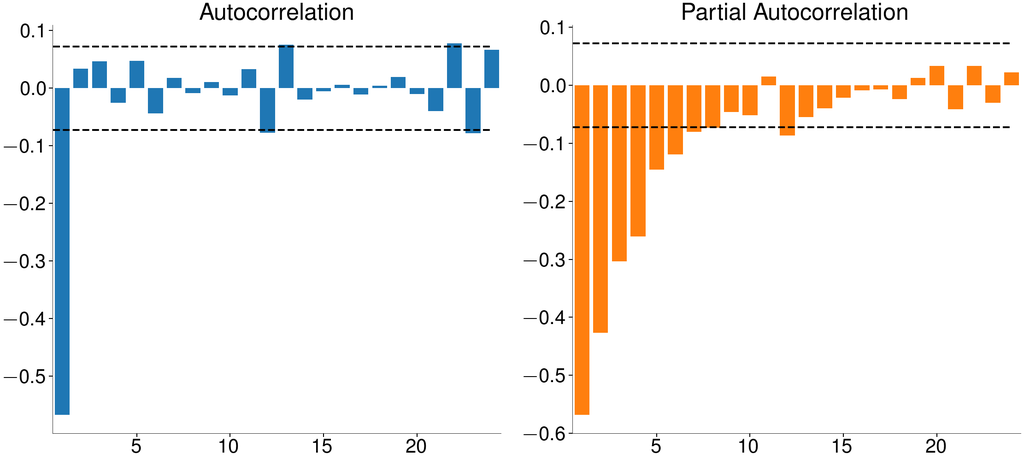

```python
acf_pacf_plot(uscons, 24)
```

# Housing Start Growth Rate

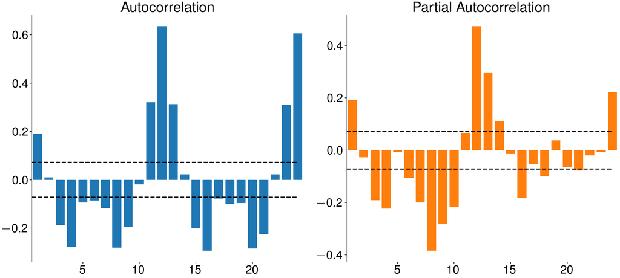

```python
acf_pacf_plot(housing, 24)
```

# US Construction Worker Growth Rate

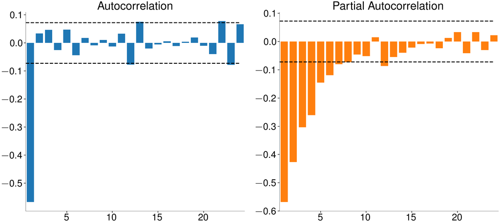

```python
acf_pacf_plot(uscons, 24)
```

# Value-Weighted Market

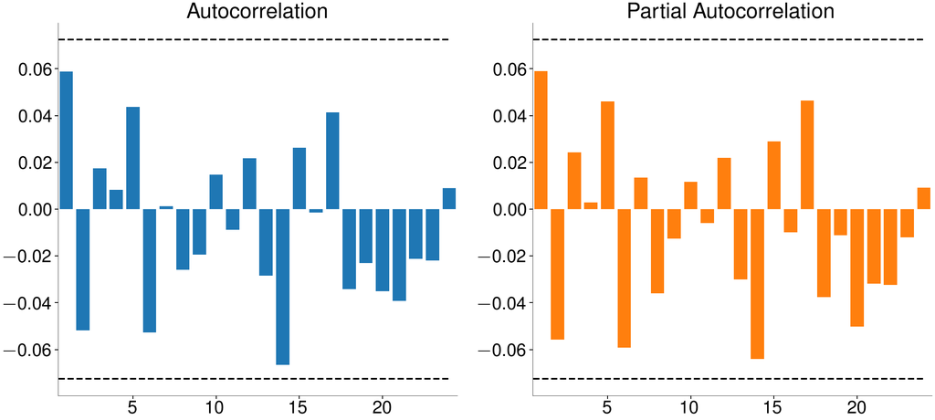

```python
acf_pacf_plot(vwm, 24)
```

# Fitting an initial model

- Begin with an AR(1) with a constant to Industrial Production Growth

$$ Y_t = \phi_0 + \phi_1 Y_{t-1} + \epsilon_t $$

- $\epsilon_t \sim WN\left(0,\sigma^2\right) $
- A process $\{\epsilon_{t}\}$ is known as white noise if

$$ \begin{align} \mathrm{E}\left[\epsilon_{t}\right] & =0 \hspace{1em}\mbox{ }\text{ for }t=1,2,\ldots \\ \mathrm{V}\left[\epsilon_{t}\right] & =\sigma^{2}<\infty \hspace{1em}\mbox{ }\text{ for }t=1,2,\ldots \\ \mathrm{E}\left[\epsilon_{t}\epsilon_{t-j}\right] & =0 \hspace{1em}\mbox{ }\text{ for }t=1,2,\ldots,\mbox{ }j\neq0 \end{align} $$

- Estimate parameters using Exact MLE
  - Discard $\max(P,Q)$ residuals
  - Model parameters include $\sigma^2\equiv\mathrm{V}\left[\epsilon_t\right]$

# Industrial Production Growth

```python
mod = SARIMAX(indpro, order=(1, 0, 0), trend="c")
res = mod.fit()
summary(res)
```

|  | coef | std err | z | P>\|z\| | [0.025 | 0.975] |
| --- | --- | --- | --- | --- | --- | --- |
| intercept | 0.0780 | 0.046 | 1.708 | 0.088 | -0.011 | 0.167 |
| ar.L1 | 0.9673 | 0.007 | 132.070 | 0.000 | 0.953 | 0.982 |
| sigma2 | 1.5703 | 0.027 | 58.347 | 0.000 | 1.518 | 1.623 |

# Diagnostics

- Plot residuals
- Residual Autocorrelations and Partial Autocorrelations
- Ljung-Box Q Test
- LM Test of Serial Correlation

# Model Residuals

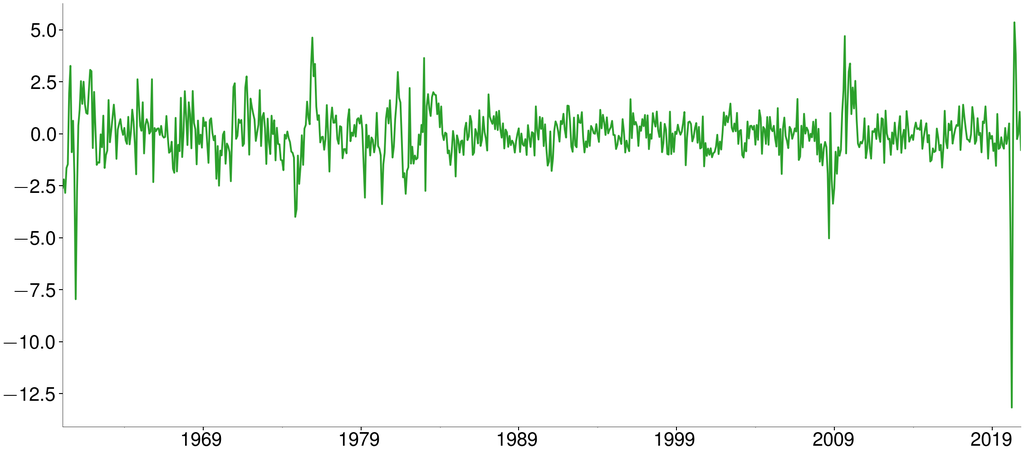

```python
resid = res.resid.iloc[1:]
plot(resid)
```

# Residual Autocorrelation

- Inference on autocorrelations

$$ \begin{align} \mathrm{V}[\hat{\rho}_{s}] = & T^{-1} \textrm{ for } s=1 \\ = & T^{-1}(1+2\sum_{j=1}^{s-1}\hat{\rho}_{j}^{2}) \textrm{ for } s>1 \end{align} $$

- Inference on partial autocorrelations

$$\mathrm{V}[\hat{\varphi}_{s}]\approx T^{-1}$$

- Confidence interval

$$ 1.96\times \sqrt{V} \approx \frac{2}{\sqrt{T}}$$

# Residual Autocorrelation

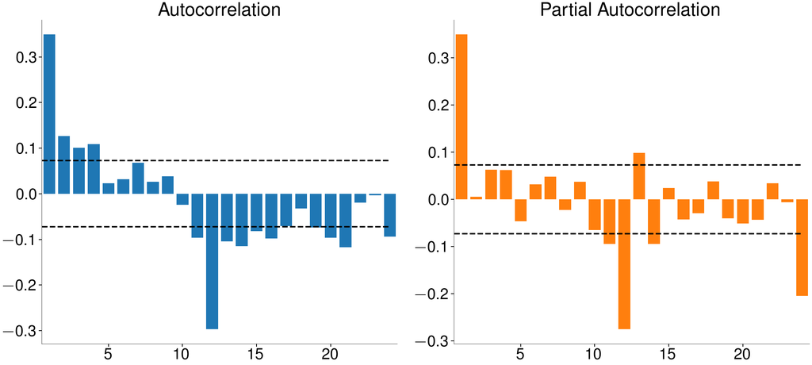

```python
acf_pacf_plot(resid, 24)
```

# Ljung-Box $Q$ Statistic

- Joint test of autocorrelations
- $H_{0}:\rho_{1}=\ldots=\rho_{s}=0$

$$ Q=T(T+2)\sum_{k=1}^{s}\frac{\hat{\rho}_{k}^{2}}{T-k}\sim\chi_{s}^{2} $$

- *Not* heteroskedasticity robust

# Residual $Q$ Statistic

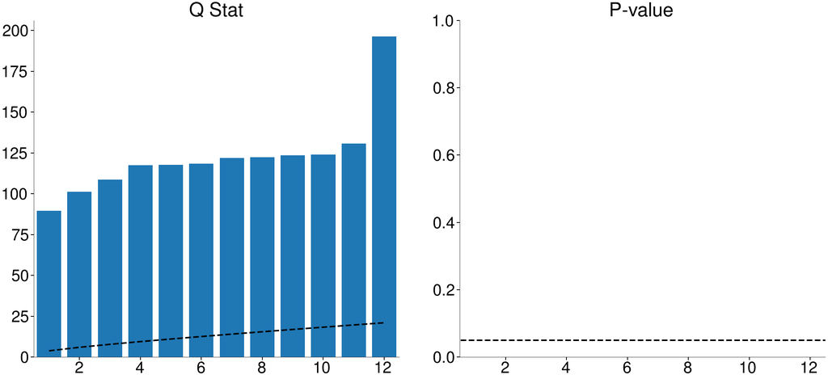

```python
lb_plot(resid, 12)
```

# LM Test for Serial Correlation

Null $\mathrm{E}[Y_{t}^{*}Y_{t-j}^{*}]=0$ for $1\leq j\leq s$ $\Longleftrightarrow$ $\rho_j=0$

The LM-test for serial correlation is constructed by defining the score vector $\mathbf{s}_{t}=Y_{t}^{*}\left[Y_{t-1}^{*}\,Y_{t-2}^{*}\,\ldots Y_{t-s}^{*}\right]'$

$$ LM=T\bar{\mathbf{s}}'\hat{\mathbf{S}}^{-1}\bar{\mathbf{s}}\stackrel{d}{\rightarrow}\chi_{s}^{2} $$

- $\bar{\mathbf{s}}=T^{-1}\sum_{t=1}^{T}\mathbf{s}_{t}$
- $\hat{\mathbf{S}}=T^{-1}\sum_{t=1}^{T}\mathbf{s}_{t}\mathbf{s}_{t}'$
- $Y_{t}^{*}=Y_{t}-T^{-1}\sum_{t=1}^{T}Y_{t}$
- *Heteroskedasticity robust*

# LM Stat and P-value

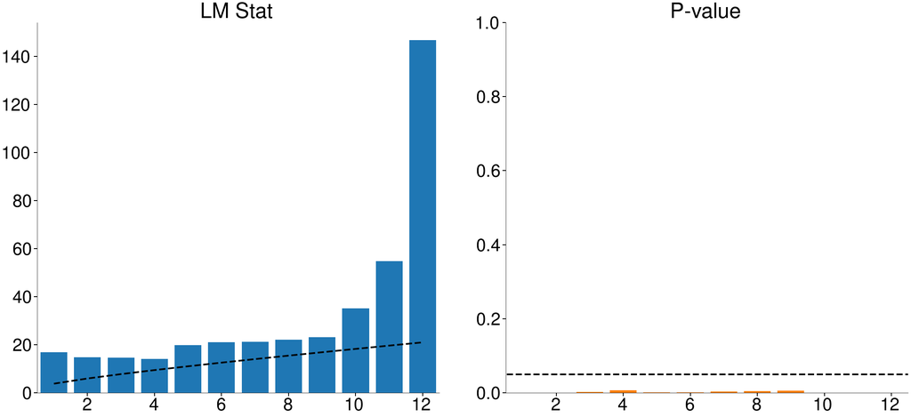

```python
lm_plot(resid, 12)
```

# Improving the Model

```python
mod = SARIMAX(indpro, order=(2, 0, 0), trend="c")
res = mod.fit()
summary(res)
```

|  | coef | std err | z | P>\|z\| | [0.025 | 0.975] |
| --- | --- | --- | --- | --- | --- | --- |
| intercept | 0.1106 | 0.045 | 2.453 | 0.014 | 0.022 | 0.199 |
| ar.L1 | 1.3187 | 0.017 | 79.114 | 0.000 | 1.286 | 1.351 |
| ar.L2 | -0.3643 | 0.018 | -20.624 | 0.000 | -0.399 | -0.330 |
| sigma2 | 1.3635 | 0.028 | 48.775 | 0.000 | 1.309 | 1.418 |

# Characteristic Roots

$$ Y_t = \phi_0 + \phi_1 Y_{t-1} + \phi_2 Y_{t-2} +\epsilon_t $$

*Note*: We will formalize testing for **unit roots** later

```python
poly = np.array([1, -res.params["ar.L1"], -res.params["ar.L2"]])
poly
```

```
array([ 1.        , -1.31873208,  0.3642808 ])
```

```python
np.roots(poly)
```

```
array([0.92485196, 0.39388012])
```

# AR(2) Residuals

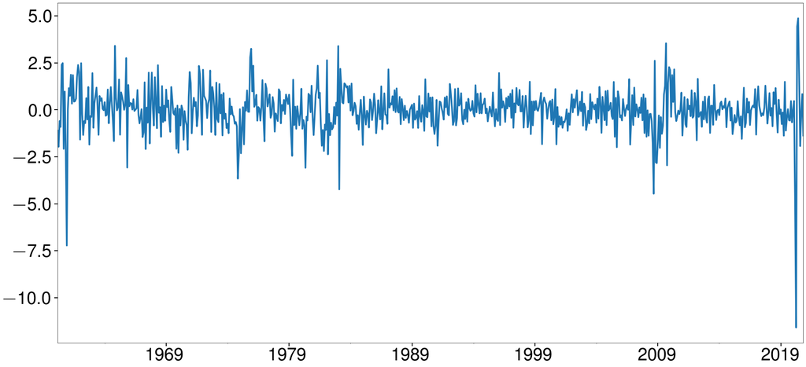

```python
resid = res.resid.iloc[2:]
_ = resid.plot()
```

# AR(2) Residual Autocorrelation

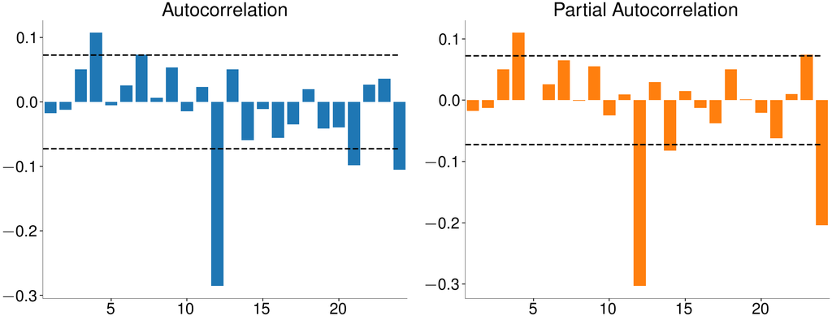

```python
acf_pacf_plot(resid, 24)
```

# AR(2) $Q$ stat

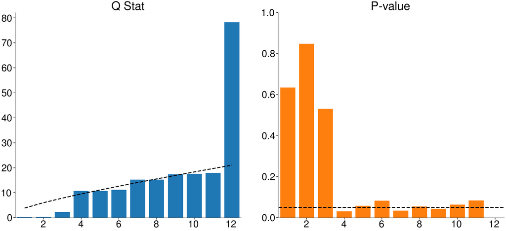

```python
lb_plot(resid, 12)
```

# Modeling US Construction Worker Growth Rate

- Sample AC and PAC indicate an MA is needed

```python
summary(res_ma1)
```

|  | coef | std err | z | P>\|z\| | [0.025 | 0.975] |
| --- | --- | --- | --- | --- | --- | --- |
| intercept | 2.063e-06 | 3.57e-05 | 0.058 | 0.954 | -6.79e-05 | 7.21e-05 |
| ma.L1 | -0.9334 | 0.009 | -102.611 | 0.000 | -0.951 | -0.916 |
| sigma2 | 0.0001 | 1.33e-06 | 86.853 | 0.000 | 0.000 | 0.000 |

# MA(2)

```python
summary(res_ma2)
```

|  | coef | std err | z | P>\|z\| | [0.025 | 0.975] |
| --- | --- | --- | --- | --- | --- | --- |
| intercept | 8.191e-07 | 2.68e-05 | 0.031 | 0.976 | -5.18e-05 | 5.34e-05 |
| ma.L1 | -1.0244 | 0.012 | -88.805 | 0.000 | -1.047 | -1.002 |
| ma.L2 | 0.0777 | 0.014 | 5.392 | 0.000 | 0.049 | 0.106 |
| sigma2 | 0.0001 | 1.16e-06 | 91.835 | 0.000 | 0.000 | 0.000 |

# MA(3)

```python
summary(res_ma3)
```

|  | coef | std err | z | P>\|z\| | [0.025 | 0.975] |
| --- | --- | --- | --- | --- | --- | --- |
| intercept | 4.276e-06 | 8.31e-05 | 0.051 | 0.959 | -0.000 | 0.000 |
| ma.L1 | -1.0516 | 0.012 | -85.452 | 0.000 | -1.076 | -1.027 |
| ma.L2 | 0.1228 | 0.021 | 5.933 | 0.000 | 0.082 | 0.163 |
| ma.L3 | 0.0982 | 0.022 | 4.381 | 0.000 | 0.054 | 0.142 |
| sigma2 | 0.0001 | 1.21e-06 | 88.482 | 0.000 | 0.000 | 0.000 |

# MA(3) Residual Analysis

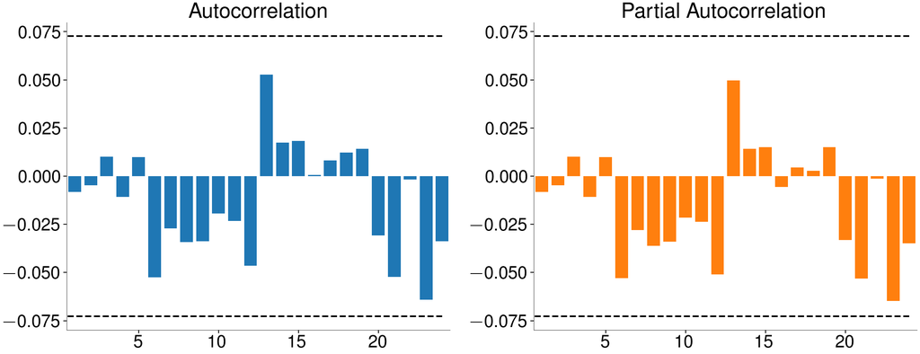

```python
resid = res_ma3.resid.iloc[3:]
acf_pacf_plot(resid, 24)
```

# MA(3) Ljung-Box $Q$ Statistic

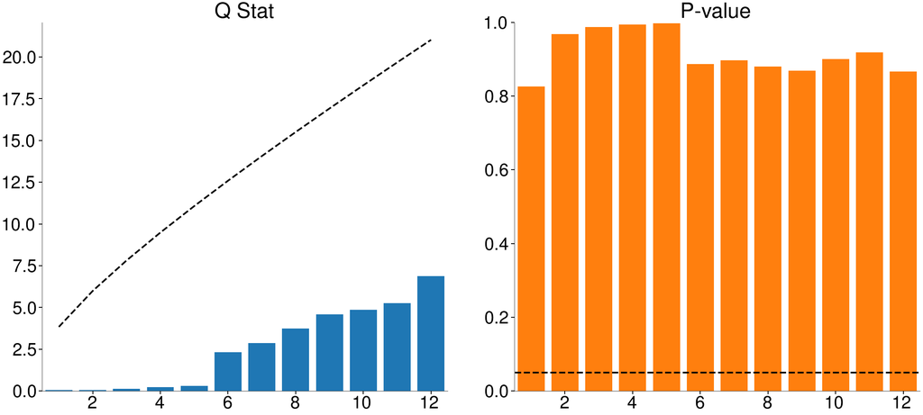

```python
lb_plot(resid, 12)
```

# MA(1) Residual Analysis

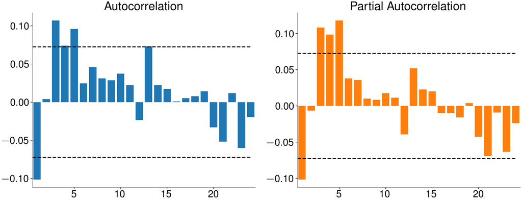

```python
resid = res_ma1.resid.iloc[3:]
acf_pacf_plot(resid, 24)
```

# MA(1) $Q$ Statistic

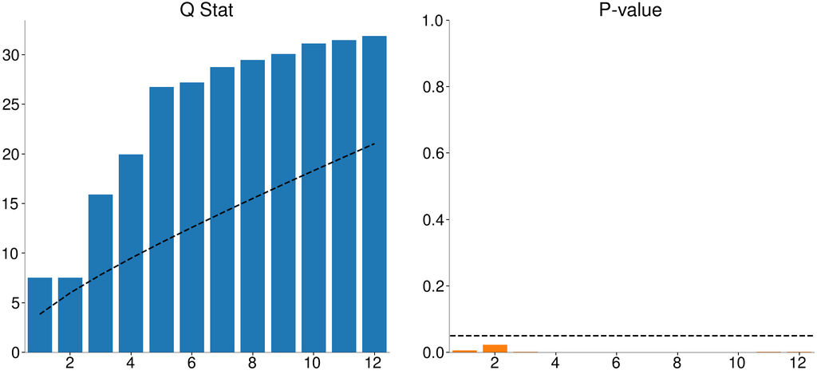

```python
lb_plot(resid, 12)
```

# Correct Specification Benchmark AR(2)

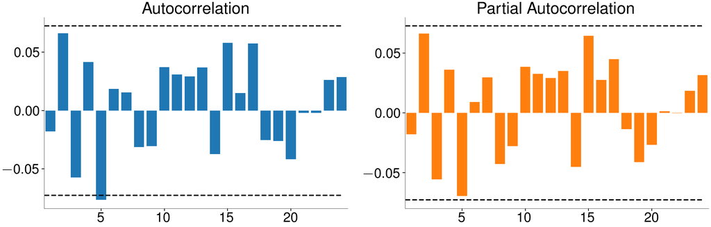

```python
res = SARIMAX(sim, order=(2, 0, 0), trend="c").fit()
resid = res.resid.iloc[2:]
acf_pacf_plot(resid, 24)
```

# LB $Q$ Stat on AR(2)

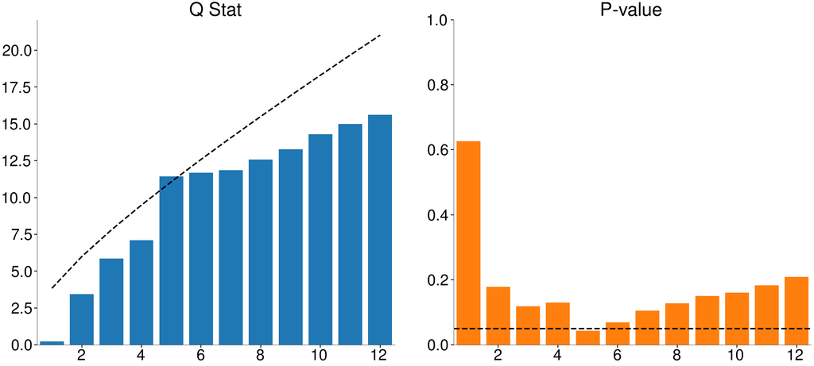

```python
lb_plot(resid, 12)
```

# StG Model Building

- Add either AR or MA
- Increase model complexity when statistically different using test size $\alpha \leq 5\%$
- Stop when no excluded lag is significant